# Impacts of clear cutting on Pacific Giant Salamander size and abundance in the Andrews Experimental Forest

Gabriel De La Rosa

11/27/2019

## Introduction

Pacific Giant Salamander (*Dicamptodon tenebrosus*) shares habitat with significant logging operations in the Pacific Northwest (Dudaniec & Richardson, 2012). Logging effects on amphibian populations affect different amphibian life stages in different ways. Larval and oviposition stages are positively affected by logging, whereas juvenile and adult stages are negatively affected (Semlitsch et al. 2009). Logging disturbance has been shown to negatively affect Pacific Giant Salamander recovery in certain areas (Ferguson, 2000). In this report, we explore how logging affects Pacific Giant Salamander abundance and size in the Andrews Experimental Forest in Oregon. Salamander size and abundance was compared between clear cut and old growth forest plots. We find salamander size and abundance is better predicted by stream characteristics than forest type. Logging operations that maintain certain preferred stream types can likely sustain Pacific Giant Salamander populations even when clear cutting.

[figure not shown]

*Pacific Giant Salamander. Photo: John Clare*

## Data and methods

Salamander weight measurements and abundance data were collected and provided by the [Andrews Experimental Forest Long Term Environmental Research Program.](https://portal.lternet.edu/nis/mapbrowse?packageid=knb-lter-and.4027.12) Vertibrate stream surveys were conducted yearly via 50m electroshocking passes in two standard 150m reaches of forest: one old growth, and one clear cut (ca. 1963). 50m pass sections were separated with nets during sampling. Captured vertibrates from these passes were weighed and counted. Salamander location was recorded as cascade, riffle, isolated pool, pool, rapid, step, or side channel.

Salamander counts were compared for forest type and stream location using a $\chi$<sup>2</sup> test ($\alpha$ = 0.5 throughout). Mean weights were compared between forest types using a two-sample t-test. Mean weights were compared between stream types using a one-way ANOVA and post-hoc Tukey HSD test. Assumptions of equal variance for weight samples between different stream types were confirmed using Levene’s test.

## Results

### A.

Salamander counts in old growth and clear cut sections of forest were compared over time. Generally, salamander abundance in old growth sections of forest exceeds abundance in clear cut sections of forest. However, since 2015, counts in clear cut sections have surpassed those in old growth sections of forest.

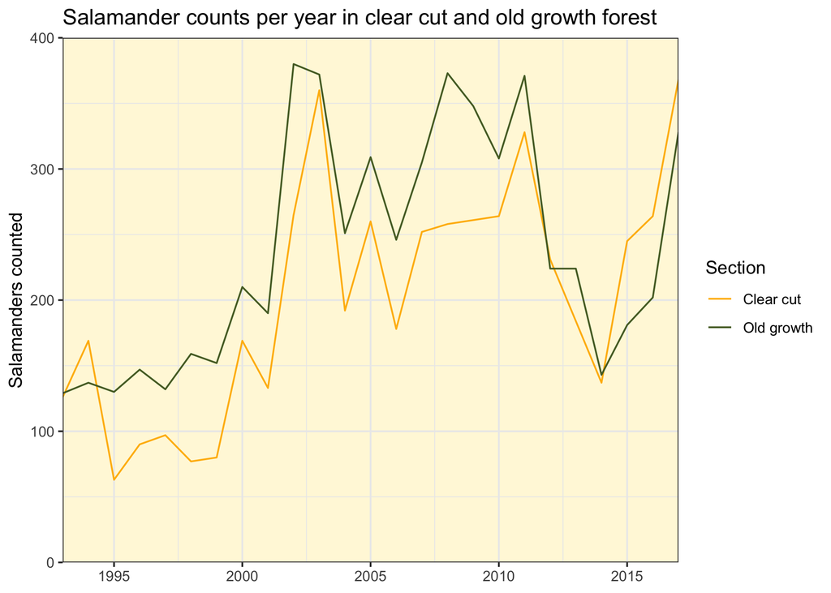

**Figure 1.** *Salamander counts per year in old growth and clear cut sections of forest.*

### B.

| Salamander counts by forest type and stream location | Salamander counts by forest type and stream location Clear Cut | Salamander counts by forest type and stream location Old Growth |
| --- | --- | --- |
| Channel | 247 (55.13%) | 201 (44.87%) |
| Pool | 31 (40.79%) | 45 (59.21%) |
| Side Channel | 90 (54.88%) | 74 (45.12%) |

**Table 1.** *Counts of where salamanders were observed, by forest type (Clear cut or old growth) and stream location (Channel, pool, or side channel). Percentages refer to proportion of counts in each forest type, by stream location.*

### C.

Salamanders were most often found in channels (n = 448), followed by side channels (n = 164), and then pools (n = 76). Forest type had no significant effect on where salamanders reside in streams ($\chi$<sup>2</sup> (2) = 5.54, *p* = 0.06).

### D.

Forest type also had no significant effect on salamander weights (t(692.79) = -1.67, *p* = 0.1 However, on average, salamanders found in clear cut sections of forest weighed over a gram more (mean = 7.78g) than salamanders in old growth sections (mean = 6.58g). Data was widely spread in both forest types (clear cut sd = 9.9g, old growth sd = 9.0g), reducing robustness of the parametric test used. This is likely due to strong positive skew in weight data, where just a few salamanders weighed significantly more than the mean (Figure 2.).

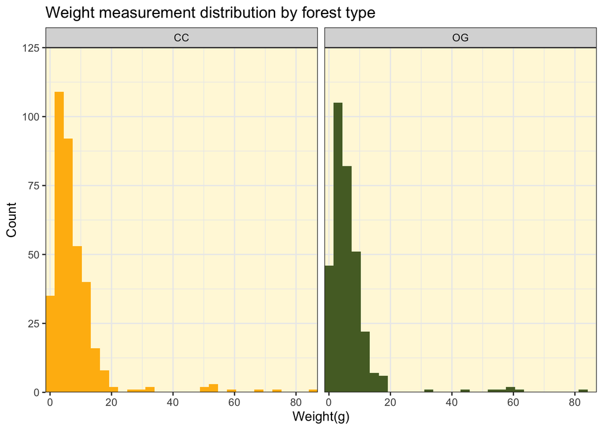

### E.

Weight measurements for salamanders found in channels are positively skewed. Comparing medians between groups, rather than means, may better describe differences between groups, as medians are less affected by skew than means. This would mainly effect the mean of salamanders found in channels, which have a few uncharacteristically heavy individuals pulling the mean heavier.

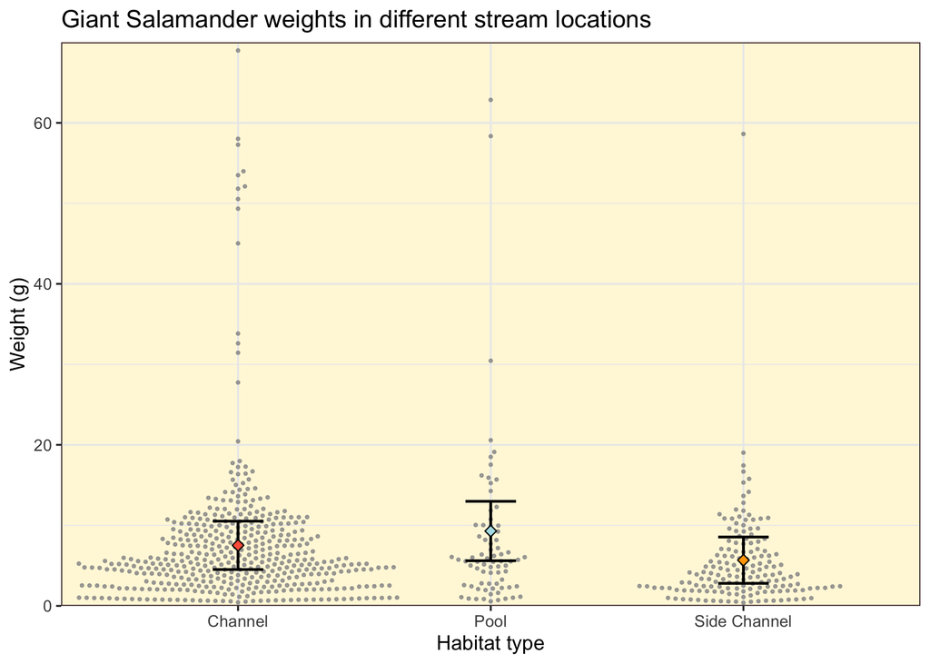

**Figure 3.** *Giant salamander weight measurements for channel, pool, and side channel stream locations. Colored diamonds represent means, errorbars are one standard deviation from the mean in either direction.*

## Summary

- Salamander abundance is better predicted by stream location than forest type (Figure 3.).
- Historically, old growth forest had more salamanders than clear cut forest. However, as of 2015, more salamanders were observed in clear cut forests (Figure 1.).
- Most salamanders, and most heavy salamanders, are found in channels. This suggests that channels are crucial salamander habitat (Figure 3.).
- Salamander populations in Mack Creek are mainly comprised of relatively lightweight individuals, suggesting salamanders may have short lifespans (Figure 2.).

## References

Dudaniec and Richardson—HABITAT ASSOCIATIONS OF THE COASTAL GIANT SALAMAND.pdf. (n.d.). Retrieved from http://herpconbio.org/Volume_7/Issue_1/Dudaniec_Richardson_2012.pdf Dudaniec, R. Y., & Richardson, J. S. (n.d.). HABITAT ASSOCIATIONS OF THE COASTAL GIANT SALAMANDER (DICAMPTODON TENEBROSUS) AT ITS NORTHERN RANGE LIMIT. Herpetological Conservation and Biology, 15.

Ferguson, H. (2000). Larval colonisation and recruitment in the Pacific giant salamander ( Dicamptodon tenebrosus ) in British Columbia. Canadian Journal of Zoology-Revue Canadienne De Zoologie - CAN J ZOOL, 78, 1238–1242. https://doi.org/10.1139/cjz-78-7-1238

Gregory S. V. 2016. Aquatic Vertebrate Population Study in Mack Creek, Andrews Experimental Forest, 1987 to present. Environmental Data Initiative. https://doi.org/10.6073/pasta/5de64af9c11579266ef20da2ff32f702. Dataset accessed 11/19/2019.

Semlitsch, R. D., Todd, B. D., Blomquist, S. M., Calhoun, A. J. K., Gibbons, J. W., Gibbs, J. P., … Rothermel, B. B. (2009). Effects of Timber Harvest on Amphibian Populations: Understanding Mechanisms from Forest Experiments. BioScience, 59(10), 853–862. https://doi.org/10.1525/bio.2009.59.10.7